# Data Project 3

Mohamed Diallo

4/27/2022

```r
library(here)
library(tidyverse)
library(readxl)
library(ggthemes)
path <- here(getwd())
```

### Introduction

This data project will be analyzing the **Anime** data-set pulled from the MyAnimeList databases. As an anime fanatic, I am quite familiarized with the MyAnimeList (MAL) website and app. I have been keeping records of the anime I watch through this website for years through their app and can state with a certain level of confidence (lol) that I represent a certain percentage of the ratings present in their databases. As of 2008, MAL apparently had 4.4million anime and 775,000 manga entries. These entries were accessed by an approximate figure nearing 120 million visitors a month in 2015.

The aim of this project will be to see the effect that the genre and type of an anime title have on their scores. This will show us to a certain extent whether the fan preferences in terms of genre and or type have an effect on the rating scores of the titles.

## Data Exploration

Let’s first start by getting a glimpse of our data:

```r
anime_raw <- read_csv(here(path, "Anime Dataset/raw_anime.csv"))
summary(anime_raw)
```

```
##     animeID          name           title_english      title_japanese
##  Min.   :    1   Length:15278       Length:15278       Length:15278
##  1st Qu.: 5209   Class :character   Class :character   Class :character
##  Median :18308   Mode  :character   Mode  :character   Mode  :character
##  Mean   :19003
##  3rd Qu.:33026
##  Max.   :39199
##
##  title_synonyms         type              source           producers
##  Length:15278       Length:15278       Length:15278       Length:15278
##  Class :character   Class :character   Class :character   Class :character
##  Mode  :character   Mode  :character   Mode  :character   Mode  :character
##
##
##
##
##     genre              studio             episodes          status
##  Length:15278       Length:15278       Min.   :   1.00   Length:15278
##  Class :character   Class :character   1st Qu.:   1.00   Class :character
##  Mode  :character   Mode  :character   Median :   2.00   Mode  :character
##                                        Mean   :  11.73
##                                        3rd Qu.:  12.00
##                                        Max.   :3057.00
##                                        NA's   :546
##    airing           aired             duration            rating
##  Mode :logical   Length:15278       Length:15278       Length:15278
##  FALSE:14892     Class :character   Class :character   Class :character
##  TRUE :381       Mode  :character   Mode  :character   Mode  :character
##  NA's :5
##
##
##
##      score          scored_by            rank         popularity
##  Min.   : 1.000   Min.   :      0   Min.   :    0   Min.   :    0
##  1st Qu.: 5.600   1st Qu.:     47   1st Qu.: 3448   1st Qu.: 3855
##  Median : 6.370   Median :    470   Median : 6932   Median : 7769
##  Mean   : 6.285   Mean   :  12107   Mean   : 6917   Mean   : 7742
##  3rd Qu.: 7.050   3rd Qu.:   3857   3rd Qu.:10416   3rd Qu.:11627
##  Max.   :10.000   Max.   :1107955   Max.   :13838   Max.   :15474
##  NA's   :500      NA's   :5         NA's   :1609    NA's   :5
##     members          favorites          synopsis          background
##  Min.   :      0   Min.   :     0.0   Length:15278       Length:15278
##  1st Qu.:    244   1st Qu.:     0.0   Class :character   Class :character
##  Median :   1630   Median :     2.0   Mode  :character   Mode  :character
##  Mean   :  24507   Mean   :   329.5
##  3rd Qu.:  10472   3rd Qu.:    23.0
##  Max.   :1610561   Max.   :120331.0
##  NA's   :5         NA's   :5
##   premiered          broadcast           related
##  Length:15278       Length:15278       Length:15278
##  Class :character   Class :character   Class :character
##  Mode  :character   Mode  :character   Mode  :character
##
##
##
##
```

```r
anime_tidy <- read_csv(here(path, "Anime Dataset/tidy_anime.csv"))
summary(anime_tidy)
```

```
##     animeID          name           title_english      title_japanese
##  Min.   :    1   Length:77911       Length:77911       Length:77911
##  1st Qu.: 3052   Class :character   Class :character   Class :character
##  Median :13667   Mode  :character   Mode  :character   Mode  :character
##  Mean   :16863
##  3rd Qu.:31452
##  Max.   :39197
##
##  title_synonyms         type              source           producers
##  Length:77911       Length:77911       Length:77911       Length:77911
##  Class :character   Class :character   Class :character   Class :character
##  Mode  :character   Mode  :character   Mode  :character   Mode  :character
##
##
##
##
##     genre              studio             episodes         status
##  Length:77911       Length:77911       Min.   :   1.0   Length:77911
##  Class :character   Class :character   1st Qu.:   1.0   Class :character
##  Mode  :character   Mode  :character   Median :  12.0   Mode  :character
##                                        Mean   :  15.8
##                                        3rd Qu.:  13.0
##                                        Max.   :3057.0
##                                        NA's   :987
##    airing          start_date            end_date            duration
##  Mode :logical   Min.   :1917-01-01   Min.   :1962-02-02   Length:77911
##  FALSE:76528     1st Qu.:2002-09-01   1st Qu.:2005-06-02   Class :character
##  TRUE :1383      Median :2011-01-22   Median :2012-06-02   Mode  :character
##                  Mean   :2007-03-14   Mean   :2009-03-29
##                  3rd Qu.:2015-09-18   3rd Qu.:2016-03-02
##                  Max.   :2019-02-03   Max.   :2019-09-02
##                  NA's   :238          NA's   :33824
##     rating              score          scored_by            rank
##  Length:77911       Min.   : 1.000   Min.   :      0   Min.   :    1
##  Class :character   1st Qu.: 6.360   1st Qu.:    597   1st Qu.: 1530
##  Mode  :character   Median : 7.020   Median :   7130   Median : 3685
##                     Mean   : 6.894   Mean   :  43495   Mean   : 4557
##                     3rd Qu.: 7.550   3rd Qu.:  39876   3rd Qu.: 6724
##                     Max.   :10.000   Max.   :1107955   Max.   :13838
##                     NA's   :174
##    popularity       members          favorites        synopsis
##  Min.   :    1   Min.   :      6   Min.   :     0   Length:77911
##  1st Qu.: 1064   1st Qu.:   1968   1st Qu.:     2   Class :character
##  Median : 3033   Median :  18214   Median :    40   Mode  :character
##  Mean   : 4567   Mean   :  85051   Mean   :  1468
##  3rd Qu.: 7394   3rd Qu.:  88560   3rd Qu.:   413
##  Max.   :15474   Max.   :1610561   Max.   :120331
##
##   background         premiered          broadcast           related
##  Length:77911       Length:77911       Length:77911       Length:77911
##  Class :character   Class :character   Class :character   Class :character
##  Mode  :character   Mode  :character   Mode  :character   Mode  :character
##
##
##
##
```

$$R = \frac{vS + mC}{v + m}$$

where v stands for total number of user votes, S for the average user score, m for the minimum number of votes required to get a calculated score (currently 50), and C for the average score across the entire anime/manga database. Only scores where a user has completed at least 20% of the anime/manga are calculated. I have included this information in case you would like to verify the accuracy of this equation or have improvements to suggest for it.[Wikipedia](https://en.wikipedia.org/wiki/MyAnimeList)

## Data Plotting

Next, let us create a violin-jitter-box-plot in order to see how the scores of anime titles differ by genre:

```r
anime_tidy <- anime_tidy %>%
  select(animeID, name, type, source, genre, studio,
         episodes, airing, start_date, end_date, duration,
         rating, score, scored_by, rank, popularity,
         members, favorites) %>%
  filter(scored_by >= 50) %>%
  drop_na(genre, score) %>%
  arrange(-score)
```

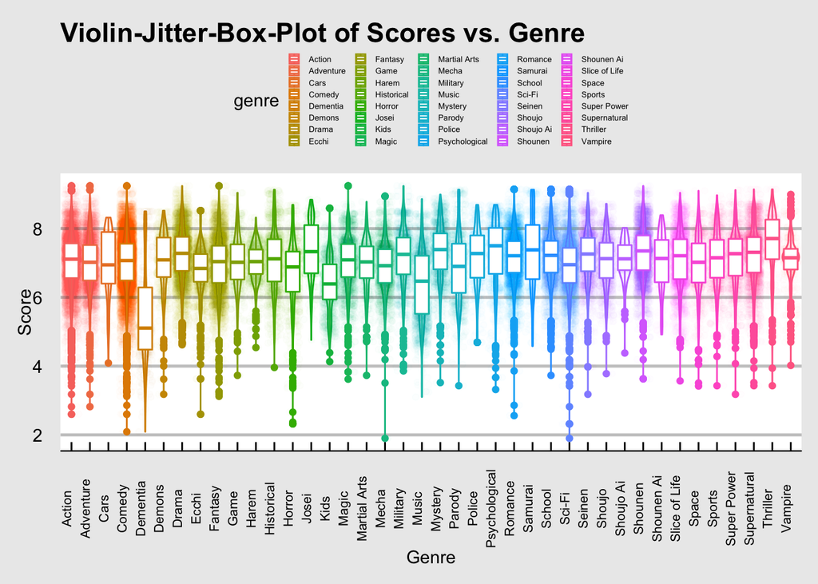

```r
ggplot(anime_tidy, aes(x = genre, y = score, color = genre)) +
  geom_violin() +
  geom_jitter(alpha = 0.01) +
  geom_boxplot() +
  scale_fill_discrete() +
  theme_economist_white() +
  theme(axis.text.x = element_text(angle = 90, size = 8),
        legend.text = element_text(size = 5),
        legend.key.size = unit(0.5, "line")) +
  labs(title = "Violin-Jitter-Box-Plot of Scores vs. Genre", x = "Genre", y = "Score")
```

We can see from the plot above that there is not much difference between the score distribution between genres therefore it is unlikely that genres have an effect on the overall score of a title given the asymmetry of certain boxes and the numerous outliers which may mess with our ANOVA test. This can be further seen in the bar-plot here-under:

```r
mean_score <- anime_tidy %>%
  filter(scored_by >= 50) %>%
  group_by(genre) %>%
  summarise_at(vars(score), list(m_score = mean))
summary(mean_score)
```

```
##     genre              m_score
##  Length:40          Min.   :5.485
##  Class :character   1st Qu.:6.968
##  Mode  :character   Median :7.057
##                     Mean   :7.017
##                     3rd Qu.:7.169
##                     Max.   :7.544
```

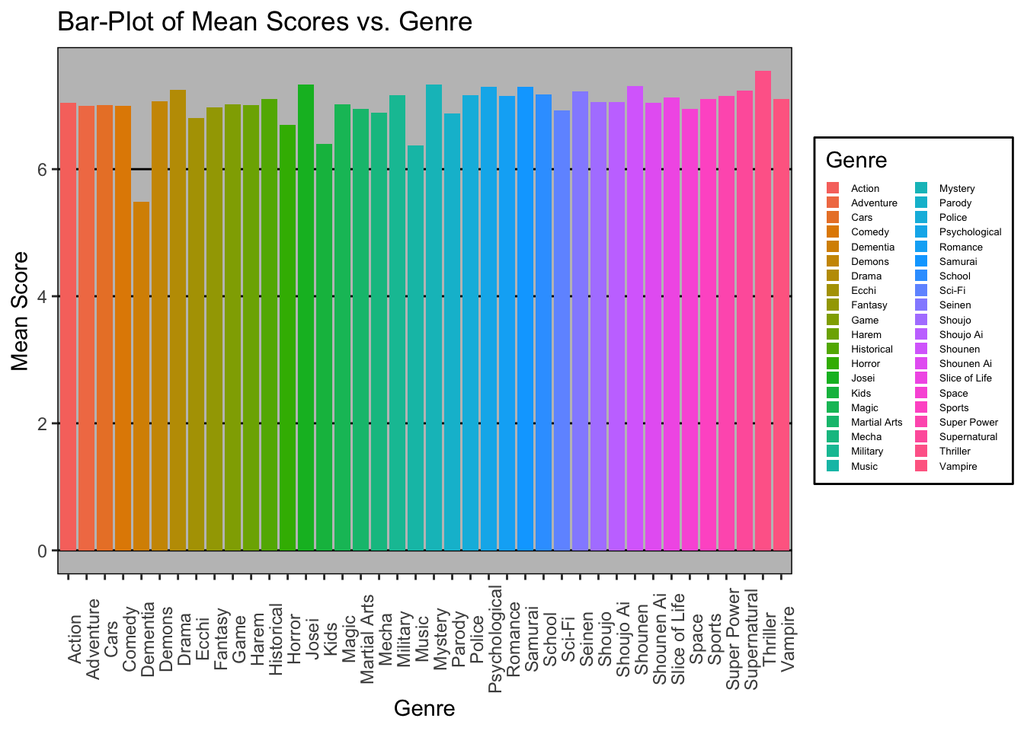

```r
ggplot(mean_score, aes(x = genre, y = m_score, fill = genre)) +
  geom_col() +
  theme_excel() +
  theme(axis.text.x = element_text(angle = 90),
        legend.text = element_text(size = 5),
        legend.key.size = unit(0.5, "line")) +
  scale_fill_hue(name = "Genre") +
  labs(title = "Bar-Plot of Mean Scores vs. Genre", x = "Genre", y = "Mean Score")
```

The bar-plot here-above shows us that there is not much mean score difference between different genres of anime. We will however still proceed with the test to see what outcome we get. Before we get to the anova test, we will first go through the effect of type on anime scores and then perform the two ANOVA tests concurrently:

```r
score_tidy <- anime_tidy %>%
  filter(scored_by >= 50) %>%
  group_by(animeID, name, genre, score, scored_by, airing, type)
summary(score_tidy)
```

```
##     animeID          name               type              source
##  Min.   :    1   Length:69887       Length:69887       Length:69887
##  1st Qu.: 2594   Class :character   Class :character   Class :character
##  Median :11307   Mode  :character   Mode  :character   Mode  :character
##  Mean   :15598
##  3rd Qu.:30654
##  Max.   :39094
##
##     genre              studio             episodes         airing
##  Length:69887       Length:69887       Min.   :   1.00   Mode :logical
##  Class :character   Class :character   1st Qu.:   1.00   FALSE:68993
##  Mode  :character   Mode  :character   Median :  12.00   TRUE :894
##                                        Mean   :  16.07
##                                        3rd Qu.:  13.00
##                                        Max.   :1818.00
##                                        NA's   :499
##    start_date            end_date            duration
##  Min.   :1917-02-01   Min.   :1962-02-02   Length:69887
##  1st Qu.:2003-07-26   1st Qu.:2005-10-02   Class :character
##  Median :2011-04-16   Median :2012-06-02   Mode  :character
##  Mean   :2007-10-14   Mean   :2009-07-16
##  3rd Qu.:2015-10-02   3rd Qu.:2016-03-02
##  Max.   :2019-02-03   Max.   :2019-09-02
##  NA's   :18           NA's   :27796
##     rating              score         scored_by            rank
##  Length:69887       Min.   :1.900   Min.   :     50   Min.   :    1
##  Class :character   1st Qu.:6.530   1st Qu.:   1531   1st Qu.: 1367
##  Mode  :character   Median :7.110   Median :  10679   Median : 3240
##                     Mean   :7.044   Mean   :  48486   Mean   : 3697
##                     3rd Qu.:7.600   3rd Qu.:  46434   3rd Qu.: 5658
##                     Max.   :9.240   Max.   :1107955   Max.   :13598
##
##    popularity       members          favorites
##  Min.   :    1   Min.   :     78   Min.   :     0.0
##  1st Qu.:  918   1st Qu.:   4314   1st Qu.:     6.0
##  Median : 2500   Median :  26148   Median :    68.0
##  Mean   : 3583   Mean   :  94792   Mean   :  1636.8
##  3rd Qu.: 5572   3rd Qu.: 107871   3rd Qu.:   528.5
##  Max.   :14518   Max.   :1610561   Max.   :120331.0
##
```

Next, we can plot the score distribution of the different types of anime. Since MAL uses a minimum number of 50 votes to rank and score a title, we will be filtering out all the titles that were scored by less than 50 people (this was also done for the previous tibbles):

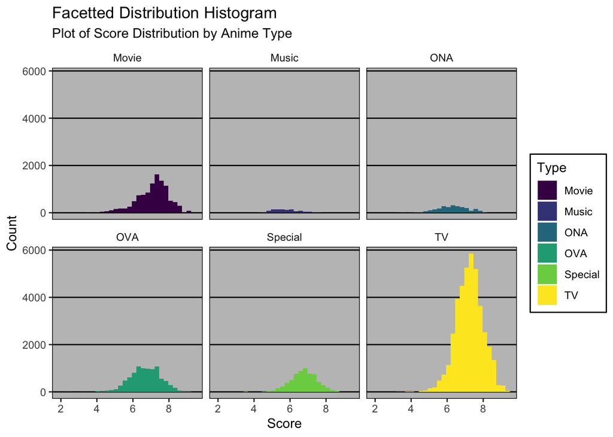

```r
ggplot(score_tidy, aes(x = score, fill = type)) +
  geom_histogram() +
  scale_fill_viridis_d(name = "Type") +
  theme(axis.text.x = element_text(size = 10),
        legend.text = element_text(size = 10),
        legend.key.size = unit(0.5, "line")) +
  facet_wrap(~type) +
  theme_excel() +
  labs(title = "Facetted Distribution Histogram",
       subtitle = "Plot of Score Distribution by Anime Type",
       x = "Score",
       y = "Count")
```

Now that we have our score distribution histograms, we can see that they skew the slightest bit towards the right indicating a higher number of high scores than low ones in the 0 - 10 scoring scale. Note that the music type is an exception to this observation as it is not skewed. We can see that all types of anime have an approximately normal distribution. Next, we plot the types versus the scores in a box-plot to better see if there is a difference in scores between different types of anime:

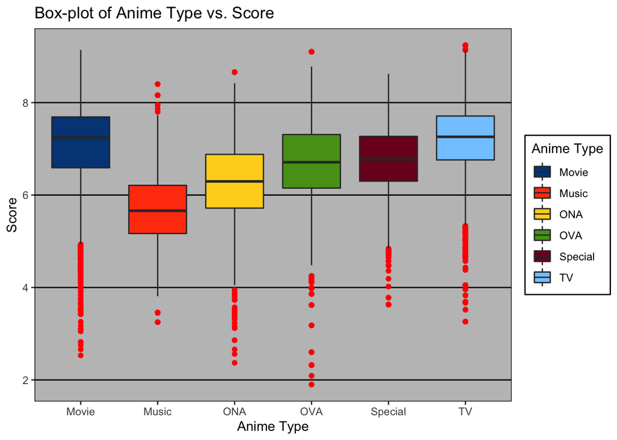

```r
ggplot(score_tidy, aes(x = type, y = score, fill = type)) +
  geom_boxplot(outlier.colour = "red") +
  scale_fill_calc(name = "Anime Type") +
  theme(axis.text.x = element_text(size = 10),
        legend.text = element_text(size = 10),
        legend.key.size = unit(0.5, "line",),
        plot.background = element_rect(colour = "black")) +
  theme_excel() +
  labs(title = "Box-plot of Anime Type vs. Score",
       x = "Anime Type",
       y = "Score")
```

We can see from this box-plot the scores tend to vary according to the type of anime. Additionally, within each of the group, the scores are symmetric and the variances seem to be similar since the boxes have approximately the same size. The last one of our assumptions has been filled by the fact that the score distributions for these different types follow a normal form.

## ANOVA Tests

The next and final step we will be taking will be to test if the type and genre of a title has any effect on the score it receives.

First, the ANOVA test with **type**:

```r
type_effct <- score_tidy %>%
  group_by(type) %>%
  summarise(score, var_score = var(score))
summary(type_effct)
```

```
##      type               score         var_score
##  Length:69887       Min.   :1.900   Min.   :0.5254
##  Class :character   1st Qu.:6.530   1st Qu.:0.5437
##  Mode  :character   Median :7.110   Median :0.5437
##                     Mean   :7.044   Mean   :0.6194
##                     3rd Qu.:7.600   3rd Qu.:0.7212
##                     Max.   :9.240   Max.   :0.8305
```

```r
model <- aov(score ~ type, data = type_effct)
summary(model)
```

```
##                Df Sum Sq Mean Sq F value Pr(>F)
## type            5   6682  1336.5    2158 <2e-16 ***
## Residuals   69881  43284     0.6
## ---
## Signif. codes:  0 '***' 0.001 '**' 0.01 '*' 0.05 '.' 0.1 ' ' 1
```

Then next the one with **genre**:

```r
genre_effct <- score_tidy %>%
  group_by(genre) %>%
  summarise(score, var_score = var(score))
summary(genre_effct)
```

```
##     genre               score         var_score
##  Length:69887       Min.   :1.900   Min.   :0.2886
##  Class :character   1st Qu.:6.530   1st Qu.:0.5820
##  Mode  :character   Median :7.110   Median :0.6732
##                     Mean   :7.044   Mean   :0.6695
##                     3rd Qu.:7.600   3rd Qu.:0.7051
##                     Max.   :9.240   Max.   :2.1549
```

```r
model <- aov(score ~ genre, data = genre_effct)
summary(model)
```

```
##                Df Sum Sq Mean Sq F value Pr(>F)
## genre          39   3203   82.13   122.7 <2e-16 ***
## Residuals   69847  46763    0.67
## ---
## Signif. codes:  0 '***' 0.001 '**' 0.01 '*' 0.05 '.' 0.1 ' ' 1
```

Surprisingly both our ANOVA tests for came back with a p-value less than 2e-16. This means that both type and genre explain the scores of anime titles. Therefore, we could technically *reject the null hypotheses* for genre and type that state that there is no association between genre and score and type and score. This means that the genre and type preferences can help explain why certain anime titles score higher than others.